# Practicum 1: R Notebook

```r
# 1. Library
# RODBC - package that implements Microsoft ODBC(Open Database Connectivity) database connectivity
# DBI - package R Database interface
# ODBC - package to connect to ODBC compatible database(using DBI interface)
# RMySQL - legacy DBI to MySQL/MariaDB
# sqldf - package for running SQL statements on R dataframe
# RSQLite - allow to connect SQLite database. use for temporary memory to load the csv
# lubridate - package for manipulating dates
library(RMySQL)
library(sqldf)
library(RSQLite)   # will be using for temporary memory to load the csv
library(lubridate) # use for dates
# library(ggplot2)   # use for the column chart

db_user <- 'root'
db_password <- '072015ead'
db_host <- 'localhost'
db_port <- 3306

# use for creating a database named birdstrikesdb
mydb = dbConnect(RMySQL::MySQL(), user=db_user, password=db_password, host=db_host)

# create a database if 'birdstrikesdb' does not exists using MySQL and R
db_name <- 'birdstrikesdb'
dbSendQuery(mydb, "CREATE DATABASE IF NOT EXISTS birdstrikesdb;")
```

```
<MySQLResult:-1539634088,4,0>
```

```r
dbSendQuery(mydb, "USE birdstrikesdb")
```

```
<MySQLResult:-1442607344,4,1>
```

```r
# reconnecting to the MySQL database that was just created
mysqlconnection <- dbConnect(RMySQL::MySQL(), dbname=db_name, host=db_host, port=db_port,
                             user=db_user, password=db_password)
sqliteconnection <- dbConnect(RSQLite::SQLite(), ":memory:")
```

List tables in database.

```r
dbListTables(mysqlconnection)
```

```
character(0)
```

Task 1(20pts / 2.5hrs):

```r
# Task 1.B, 1.C:
# airports(aid, airportName, airportCode, state)
dbSendQuery(mysqlconnection, "CREATE TABLE airports (
            aid INT NOT NULL AUTO_INCREMENT,
            airportName VARCHAR(255) NOT NULL,
            airportCode VARCHAR(50) DEFAULT NULL,
            state VARCHAR(50) NOT NULL,
            PRIMARY KEY (aid))")
```

```
<MySQLResult:1,5,1>
```

```r
# Task 1.D:
# conditions(cid, condition, explanation)
# 1: No Cloud
# 2: Overcast
# 3: Some Cloud
dbSendQuery(mysqlconnection, "CREATE TABLE IF NOT EXISTS conditions (
            cid INT(50) PRIMARY KEY AUTO_INCREMENT NOT NULL,
            sky_condition VARCHAR(50) NOT NULL,
            explanation VARCHAR(255));")
```

```
<MySQLResult:-1216267056,5,2>
```

```r
# Task 1.E
# harmonize flight_phase:
# 1: take-off - climb, take-off run
# 2: landing - landing roll, approach, descent
# 3: inflight
# 4: unknown - parked, taxi
dbSendQuery(mysqlconnection, "CREATE TABLE IF NOT EXISTS flight_phase_enum (
            fpid VARCHAR(50) PRIMARY KEY NOT NULL,
            status VARCHAR(50) NOT NULL);")
```

```
<MySQLResult:-1213434248,5,3>
```

```r
# Tasks 1.A:
# note: NO duplicates in rid
# incidents(rid, date, origin, airline, aircraft, flightPhase, altitude, conditions, warning)
dbSendQuery(mysqlconnection, "CREATE TABLE incidents (
            rid INT NOT NULL AUTO_INCREMENT,
            flight_date DATE NOT NULL,
            origin INT NOT NULL,
            airline VARCHAR(255),
            aircraft VARCHAR(50),
            mflight_phase VARCHAR(50) NOT NULL,
            altitude_ft INTEGER(50),
            msky_conditions INT(50) NOT NULL,
            pilot_warned_flag BOOLEAN,
            PRIMARY KEY (rid),
            FOREIGN KEY (origin) REFERENCES airports(aid),
            FOREIGN KEY (msky_conditions) REFERENCES conditions(cid),
            FOREIGN KEY (mflight_phase) REFERENCES flight_phase_enum (fpid));")
```

```
<MySQLResult:-1451759344,5,4>
```

List tables in database.

```r
dbListTables(mysqlconnection)
```

```
[1] "airports"          "conditions"        "flight_phase_enum" "incidents"
```

Assume “Business” to be an airline name. Include in database.

```r
# Task 1.F:
# write code to include "Business" - no need
```

Remove all “MILITARY” flights from the database

```r
# Task 1.G:
# write code to remove "MILITARY" - DONE below
```

```r
# Task 1.F:
# Use either {sql} or {r} functions. We are using R functions so that we are flexible. - using
# combination of {sql} and {r} for this practicum
```

Task 2(25pts / 5hrs):

```r
# csv file
csv_file <- "BirdStrikesData-V2.csv"

# read csv file
birdstrikesdata_csv <- read.csv(file = csv_file, header = T, stringsAsFactors = F)

# rename column names to fix the see special character in first column: 'ï..rid'
names(birdstrikesdata_csv) <- c('rid',  'aircraft', 'airport',  'model',    'wildlife_struck',
                                'impact',   'flight_date',  'damage',   'airline', 'origin',
                                'flight_phase', 'remains_collected_flag',   'Remarks',
                                'wildlife_size',    'sky_conditions', 'species',
                                'pilot_warned_flag', 'altitude_ft', 'heavy_flag')

head(birdstrikesdata_csv, 10)
```

|  | rid | aircraft | airport | model | wildlife_struck | impact | flight_date | damage | airline | origin | flight_phase | remains_collected_flag | Remarks | wildlife_size | sky_conditions | species | pilot_warned_flag | altitude_ft | heavy_flag |
| --- | --- | --- | --- | --- | --- | --- | --- | --- | --- | --- | --- | --- | --- | --- | --- | --- | --- | --- | --- |
| 1 | 202152 | Airplane | LAGUARDIA NY | B-737-400 | 859 | Engine Shut Down | 11/23/2000 0:00 | Caused damage | US AIRWAYS* | New York | Climb | FALSE | FLT 753. PILOT REPTD A HUNDRED BIRDS ON UNKN TYPE. #1 ENG WAS SHUT DOWN AND DIVERTED TO EWR. SLIGHT VIBRATION. A/C WAS OUT OF SVC FOR REPAIRS TO COWLING, FAN DUCT ACCOUSTIC PANEL. INGESTION. DENTED FA… | Medium | No Cloud | Unknown bird - medium | N | 1,500 | Yes |
| 2 | 208159 | Airplane | DALLAS/FORT WORTH INTL ARPT | MD-80 | 424 | None | 7/25/2001 0:00 | Caused damage | AMERICAN AIRLINES | Texas | Landing Roll | FALSE | 102 CARCASSES FOUND. 1 LDG LIGHT ON NOSE GEAR WAS DAMAGED AND REPLACED. | Small | Some Cloud | Rock pigeon | Y | 0 | No |
| 3 | 207601 | Airplane | LAKEFRONT AIRPORT | C-500 | 261 | None | 9/14/2001 0:00 | No damage | BUSINESS | Louisiana | Approach | FALSE | FLEW UNDER A VERY LARGE FLOCK OF BIRDS OVER APCH END OF RWY. NO DMG. JUST A LOT OF BIRD DROPPINGS ON WINDSCREEN. | Small | No Cloud | European starling | N | 50 | No |
| 4 | 215953 | Airplane | SEATTLE-TACOMA INTL | B-737-400 | 806 | Precautionary Landing | 9/5/2002 0:00 | No damage | ALASKA AIRLINES | Washington | Climb | TRUE | NOTAM WARNING. 26 BIRDS HIT THE A/C, FORCING AN EMERGENCY LDG. 77 BIRDS WERE FOUND DEAD ON RWY/TWY WITH GRASSHOPPERS IN THEIR STOMACHS. SAFETY AREAS COULD NOT BE THOROUGHLY INSPCTD DURING 14 MINUTE SH… | Small | Some Cloud | European starling | Y | 50 | Yes |
| 5 | 219878 | Airplane | NORFOLK INTL | CL-RJ100/200 | 942 | None | 6/23/2003 0:00 | No damage | COMAIR AIRLINES | Virginia | Approach | FALSE | NO DMG REPTD. | Small | No Cloud | European starling | N | 50 | No |
| 6 | 218432 | Airplane | GUAYAQUIL/S BOLIVAR | A-300 | 537 | None | 7/24/2003 0:00 | No damage | AMERICAN AIRLINES | N/A | Take-off run | FALSE | NO DMG. BIRD REMAINS ON F/O WINDSCREEN. | Small | No Cloud | Unknown bird - small | N | 0 | No |
| 7 | 221697 | Airplane | NEW CASTLE COUNTY | LEARJET-25 | 227 | Other | 8/17/2003 0:00 | Caused damage | BUSINESS | Delaware | Climb | TRUE |  | Small | No Cloud | European starling | N | 150 | No |
| 8 | 236635 | Airplane | WASHINGTON DULLES INTL ARPT | A-320 | 320 | Other | 3/1/2006 0:00 | Caused damage | UNITED AIRLINES | DC | Approach | TRUE | WS ASSISTED IN CLEAN-UP OF 273 STARLINGS AND 1 BROWN-HEADED COWBIRD FROM RWY THRESHOLD. PHOTOS OF A/C TAKEN. BORESCOPED BOTH ENGS. FOUND DENTS AND NICKS IN STAGES 3-6. ALL WITHIN LIMITS. CLEANED RADOM… | Small | Some Cloud | European starling | Y | 100 | No |
| 9 | 207369 | Airplane | ATLANTA INTL | DC-9-30 | 9 | Aborted Take-off | 1/6/2000 0:00 | No damage | AIRTRAN AIRWAYS | Georgia | Take-off run | FALSE |  | Small | Some Cloud | Rock pigeon | N | 0 | No |
| 10 | 204371 | Airplane | ORLANDO SANFORD INTL AIRPORT | A-330 | 4 | None | 1/7/2000 0:00 | No damage | AIRTOURS INTL | Florida | Landing Roll | FALSE | FLT 057 | Small | Some Cloud | Unknown bird - small | N | 0 | No |

Display the structure of the R object ‘birdstrikesdata_csv’

```r
str(birdstrikesdata_csv)
```

```
'data.frame':   25558 obs. of  19 variables:
 $ rid                   : int  202152 208159 207601 215953 219878 218432 221697 236635 207369 204371 ...
 $ aircraft              : chr  "Airplane" "Airplane" "Airplane" "Airplane" ...
 $ airport               : chr  "LAGUARDIA NY" "DALLAS/FORT WORTH INTL ARPT" "LAKEFRONT AIRPORT" "SEATTLE-TACOMA INTL" ...
 $ model                 : chr  "B-737-400" "MD-80" "C-500" "B-737-400" ...
 $ wildlife_struck       : int  859 424 261 806 942 537 227 320 9 4 ...
 $ impact                : chr  "Engine Shut Down" "None" "None" "Precautionary Landing" ...
 $ flight_date           : chr  "11/23/2000 0:00" "7/25/2001 0:00" "9/14/2001 0:00" "9/5/2002 0:00" ...
 $ damage                : chr  "Caused damage" "Caused damage" "No damage" "No damage" ...
 $ airline               : chr  "US AIRWAYS*" "AMERICAN AIRLINES" "BUSINESS" "ALASKA AIRLINES" ...
 $ origin                : chr  "New York" "Texas" "Louisiana" "Washington" ...
 $ flight_phase          : chr  "Climb" "Landing Roll" "Approach" "Climb" ...
 $ remains_collected_flag: logi  FALSE FALSE FALSE TRUE FALSE FALSE ...
 $ Remarks               : chr  "FLT 753. PILOT REPTD A HUNDRED BIRDS ON UNKN TYPE. #1 ENG WAS SHUT DOWN AND DIVERTED TO EWR. SLIGHT VIBRATION. "| __truncated__ "102 CARCASSES FOUND. 1 LDG LIGHT ON NOSE GEAR WAS DAMAGED AND REPLACED." "FLEW UNDER A VERY LARGE FLOCK OF BIRDS OVER APCH END OF RWY. NO …
 $ wildlife_size         : chr  "Medium" "Small" "Small" "Small" ...
 $ sky_conditions        : chr  "No Cloud" "Some Cloud" "No Cloud" "Some Cloud" ...
 $ species               : chr  "Unknown bird - medium" "Rock pigeon" "European starling" "European starling" ...
 $ pilot_warned_flag     : chr  "N" "Y" "N" "Y" ...
 $ altitude_ft           : chr  "1,500" "0" "50" "50" ...
 $ heavy_flag            : chr  "Yes" "No" "No" "Yes" ...
```

DO NOT USE THIS! instead use the SQLite in memory to load the raw data - this r code uses in-line write in the MySQL database.

```r
# dbWriteTable(conn = sqliteconnection,'birdstrikesdata_table', birdstrikesdata_csv, overwrite = TRUE)

# df.airlines <- sqldf::sqldf("SELECT aircraft, airline from `birdstrikesdata_csv`")
# class(birdstrikesdata_csv)
```

Function to replace commas in altitude_ft. Need to remove commas to correctly convert the data type.

```r
replaceCommas <- function(x){
  x<-as.numeric(gsub("\\,", "", x))
}
```

Create a raw dataframe from the ‘birdstrikesdata_csv’ and remove rows with empty cells.

```r
options(sqldf.driver = "SQLite")

# raw dataframe
df.raw <- sqldf::sqldf("SELECT rid, aircraft, airport, flight_date, airline, origin, flight_phase,
                       sky_conditions, pilot_warned_flag, altitude_ft FROM `birdstrikesdata_csv`",
                       drv = 'SQLite')

# remove the time component on the date
flight_date <- format(as.POSIXct(c(df.raw$flight_date),format='%m/%d/%Y %H:%M'),format='%m-%d-%Y')

# updated df.raw with timestamp removed
df.raw.updated <- data.frame(rid = df.raw$rid,
                             aircraft = df.raw$aircraft,
                             airport = df.raw$airport,
                             flight_date = flight_date,
                             airline = df.raw$airline,
                             origin = df.raw$origin,
                             flight_phase = df.raw$flight_phase,
                             sky_conditions = df.raw$sky_conditions,
                             pilot_warned_flag = df.raw$pilot_warned_flag,
                             altitude_ft = df.raw$altitude_ft)

# remove empty cell in dataframe : https://stackoverflow.com/questions/42721788/filter-empty-rows-from-a-dataframe-with-r
df.raw.noNULL <- df.raw.updated[Reduce(`&`, lapply(df.raw.updated, function(x) !(is.na(x)|x == ""))),]

# change the pilot_warned_flag to TRUE or FALSE
df.raw.noNULL$pilot_warned_flag[df.raw.noNULL$pilot_warned_flag == 'Y'] <- 1
df.raw.noNULL$pilot_warned_flag[df.raw.noNULL$pilot_warned_flag == 'N'] <- 0

# convert data type appropriately:
df.raw.noNULL$flight_date <- as.Date(df.raw.noNULL$flight_date, "%m-%d-%Y")     # convert flight_date to data type = Date
df.raw.noNULL$altitude_ft <- replaceCommas(df.raw.noNULL$altitude_ft)
df.raw.noNULL$altitude_ft <- as.integer(df.raw.noNULL$altitude_ft)              # convert altitude_ft to data type = integer
df.raw.noNULL$pilot_warned_flag <- as.integer(df.raw.noNULL$pilot_warned_flag)  # convert pilot_warned_flag to data type =                                                                                         integer(note: logical does not work when                                                                                         dbWriteTable is performed)

head(df.raw.noNULL, 10)
```

|  | rid | aircraft | airport | flight_date | airline | origin | flight_phase | sky_conditions | pilot_warned_flag | altitude_ft |
| --- | --- | --- | --- | --- | --- | --- | --- | --- | --- | --- |
| 1 | 202152 | Airplane | LAGUARDIA NY | 2000-11-23 | US AIRWAYS* | New York | Climb | No Cloud | 0 | 1500 |
| 2 | 208159 | Airplane | DALLAS/FORT WORTH INTL ARPT | 2001-07-25 | AMERICAN AIRLINES | Texas | Landing Roll | Some Cloud | 1 | 0 |
| 3 | 207601 | Airplane | LAKEFRONT AIRPORT | 2001-09-14 | BUSINESS | Louisiana | Approach | No Cloud | 0 | 50 |
| 4 | 215953 | Airplane | SEATTLE-TACOMA INTL | 2002-09-05 | ALASKA AIRLINES | Washington | Climb | Some Cloud | 1 | 50 |
| 5 | 219878 | Airplane | NORFOLK INTL | 2003-06-23 | COMAIR AIRLINES | Virginia | Approach | No Cloud | 0 | 50 |
| 6 | 218432 | Airplane | GUAYAQUIL/S BOLIVAR | 2003-07-24 | AMERICAN AIRLINES | N/A | Take-off run | No Cloud | 0 | 0 |
| 7 | 221697 | Airplane | NEW CASTLE COUNTY | 2003-08-17 | BUSINESS | Delaware | Climb | No Cloud | 0 | 150 |
| 8 | 236635 | Airplane | WASHINGTON DULLES INTL ARPT | 2006-03-01 | UNITED AIRLINES | DC | Approach | Some Cloud | 1 | 100 |
| 9 | 207369 | Airplane | ATLANTA INTL | 2000-01-06 | AIRTRAN AIRWAYS | Georgia | Take-off run | Some Cloud | 0 | 0 |
| 10 | 204371 | Airplane | ORLANDO SANFORD INTL AIRPORT | 2000-01-07 | AIRTOURS INTL | Florida | Landing Roll | Some Cloud | 0 | 0 |

Number of rows with empty cells.

```r
# get the number of rows with/without empty cells
nrow_raw <- nrow(df.raw)                           # no. of rows for raw data
nrow_rawNoNULL <- nrow(df.raw.noNULL)              # no. of rows with NULL elements in any column
total_rows_remove = nrow_raw - nrow_rawNoNULL      # total rows removed
print(paste0("Number of rows with empty cell = ", total_rows_remove))
```

```
[1] "Number of rows with empty cell = 129"
```

Create airports dataframe:

```r
grpby_airportName <- sqldf::sqldf("SELECT 1 as aid, airport, origin as state FROM `df.raw.noNULL`
                                  GROUP BY airport")

# add column airportCode with value NA
grpby_airportName[,'airportCode'] <- NA

# rename column airport to airportName
names(grpby_airportName)[names(grpby_airportName) == "airport"] <- "airportName"

# reorder the columns of grpby_airlines
col_order <- c("aid", "airportName", "airportCode", "state")

grpby_airportName_new <- grpby_airportName[, col_order]

# number of airports
n.airportName <- nrow(grpby_airportName_new)

# increment the aid starting from 1 to end
grpby_airportName_new[,1] <- seq(1, n.airportName)

# change the data type of airportCode to character
grpby_airportName_new$airportCode <- as.character(grpby_airportName_new$airportCode)

head(grpby_airportName_new, 10)
```

|  | aid | airportName | airportCode | state |
| --- | --- | --- | --- | --- |
| 1 | 1 | ABERDEEN REGIONAL AR | NA | South Dakota |
| 2 | 2 | ABILENE REGIONAL ARPT | NA | Texas |
| 3 | 3 | ABRAHAM LINCOLN CAPITAL ARPT | NA | Illinois |
| 4 | 4 | ADAMS COUNTY- LEGION FIELD | NA | Wisconsin |
| 5 | 5 | ADAMS FIELD ARPT | NA | Arkansas |
| 6 | 6 | ADDINGTON FIELD ARPT | NA | Kentucky |
| 7 | 7 | ADDISON | NA | Texas |
| 8 | 8 | ADIRONDAK REGIONAL ARPT | NA | New York |
| 9 | 9 | AIRBORNE AIRPARK | NA | Ohio |
| 10 | 10 | AKRON-CANTON MUNICIPAL | NA | Ohio |

Create conditions dataframe:

```r
grpby_conditions <- sqldf::sqldf("SELECT 1 as cid, sky_conditions FROM `df.raw.noNULL` GROUP BY
                                 sky_conditions")

# add column explanation with value NA
grpby_conditions[,'explanation'] <- NA

# number of conditions
n.conditions <- nrow(grpby_conditions)

# increment the cid starting from 1 to end
grpby_conditions[,1] <- seq(1, n.conditions)

# change the data type of explanation to character
grpby_conditions$explanation <- as.character(grpby_conditions$explanation)

grpby_conditions
```

| cid | sky_conditions | explanation |
| --- | --- | --- |
| 1 | No Cloud | NA |
| 2 | Overcast | NA |
| 3 | Some Cloud | NA |

Create flight phase dataframe:

```r
grpby_flightPhase <- sqldf::sqldf("SELECT 1 as fpid, flight_phase FROM `df.raw.noNULL` GROUP BY
                                  flight_phase")

# combining of different flight phase

# for landing:
grpby_landing <- sqldf::sqldf("SELECT GROUP_CONCAT(flight_phase, ', ') as flight_phase FROM
                              `grpby_flightPhase` WHERE flight_phase like 'approach' or
                              flight_phase like 'descent' or flight_phase like 'landing roll'")

# for takeoff
grpby_takeoff <- sqldf::sqldf("SELECT GROUP_CONCAT(flight_phase, ', ') as flight_phase FROM
                              `grpby_flightPhase` WHERE flight_phase like 'climb' or flight_phase
                              like 'take-off run'")

# for inflight
grpby_inflight <- sqldf::sqldf("SELECT GROUP_CONCAT(flight_phase, ', ') as flight_phase FROM
                               `grpby_flightPhase` WHERE flight_phase like 'inflight'")

# for unknown
grpby_unknown <- sqldf::sqldf("SELECT GROUP_CONCAT(flight_phase, ', ') as flight_phase FROM
                              `grpby_flightPhase` WHERE flight_phase like 'parked' or flight_phase
                              like 'taxi' and (flight_phase not like 'approach' or flight_phase not
                              like 'descent' or flight_phase not like 'landing roll' or flight_phase
                              not like 'climb' or flight_phase not like 'take-off run' or
                              flight_phase not like 'inflight')")

# combine the different flight phase
flight.phase.values <- c(grpby_landing$flight_phase, grpby_takeoff$flight_phase,
                         grpby_inflight$flight_phase, grpby_unknown$flight_phase)

# create a dataframe
df.flight.phase <- data.frame(fpid = seq(1,4),
                              status = flight.phase.values)

# change fpid values as per requirement
df.flight.phase[df.flight.phase == 1] <- 'landing'
df.flight.phase[df.flight.phase == 2] <- 'takeoff'
df.flight.phase[df.flight.phase == 3] <- 'inflight'
df.flight.phase[df.flight.phase == 4] <- 'unknown'

df.flight.phase
```

| fpid | status |
| --- | --- |
| landing | Approach, Descent, Landing Roll |
| takeoff | Climb, Take-off run |
| inflight | NA |
| unknown | Parked, Taxi |

Create incidents dataframe:

```r
# number of incidents are the number of rows. also each rid is unique, we can use that
# as number of incidents
# n.incidents <- sqldf::sqldf("SELECT COUNT(DISTINCT rid) FROM `df.raw.noNULL`")
n.incidents <- nrow(df.raw.noNULL)

df.incidents <- data.frame(rid = df.raw.noNULL$rid,
                           flight_date = df.raw.noNULL$flight_date,
                           origin = 1,
                           airline = df.raw.noNULL$airline,
                           aircraft = df.raw.noNULL$aircraft,
                           mflight_phase = 1,
                           altitude_ft = df.raw.noNULL$altitude_ft,
                           msky_conditions = 1,
                           pilot_warned_flag = df.raw.noNULL$pilot_warned_flag)
                           # temp_airport = df.raw.noNULL$airport)

# combine US AIRWAYS and US AIRWAYS*
df.incidents$airline[df.incidents$airline == 'US AIRWAYS*'] <- 'US AIRWAYS'

head(df.incidents, 10)
```

|  | rid | flight_date | origin | airline | aircraft | mflight_phase | altitude_ft | msky_conditions | pilot_warned_flag |
| --- | --- | --- | --- | --- | --- | --- | --- | --- | --- |
| 1 | 202152 | 2000-11-23 | 1 | US AIRWAYS | Airplane | 1 | 1500 | 1 | 0 |
| 2 | 208159 | 2001-07-25 | 1 | AMERICAN AIRLINES | Airplane | 1 | 0 | 1 | 1 |
| 3 | 207601 | 2001-09-14 | 1 | BUSINESS | Airplane | 1 | 50 | 1 | 0 |
| 4 | 215953 | 2002-09-05 | 1 | ALASKA AIRLINES | Airplane | 1 | 50 | 1 | 1 |
| 5 | 219878 | 2003-06-23 | 1 | COMAIR AIRLINES | Airplane | 1 | 50 | 1 | 0 |
| 6 | 218432 | 2003-07-24 | 1 | AMERICAN AIRLINES | Airplane | 1 | 0 | 1 | 0 |
| 7 | 221697 | 2003-08-17 | 1 | BUSINESS | Airplane | 1 | 150 | 1 | 0 |
| 8 | 236635 | 2006-03-01 | 1 | UNITED AIRLINES | Airplane | 1 | 100 | 1 | 1 |
| 9 | 207369 | 2000-01-06 | 1 | AIRTRAN AIRWAYS | Airplane | 1 | 0 | 1 | 0 |
| 10 | 204371 | 2000-01-07 | 1 | AIRTOURS INTL | Airplane | 1 | 0 | 1 | 0 |

Link the incidents, airport, conditions and flight phase dataframe:

```r
# link the dataframe incidents, airport, conditions and flight phase
for (i in 1:n.incidents) {
  a <- grpby_airportName_new$aid[which(grpby_airportName_new$airportName == df.raw.noNULL$airport[i] & grpby_airportName_new$state == df.raw.noNULL$origin[i])]
  c <- grpby_conditions$cid[which(grpby_conditions$sky_conditions == df.raw.noNULL$sky_conditions[i])]

  df.incidents$origin[i] <- a
  df.incidents$msky_conditions[i] <- c

  if (df.raw.noNULL$flight_phase[i] == 'Climb' || df.raw.noNULL$flight_phase[i] == 'Take-off run') {
    df.incidents$mflight_phase[i] <- 'takeoff'
  } else if (df.raw.noNULL$flight_phase[i] == 'Landing Roll' || df.raw.noNULL$flight_phase[i] == 'Approach' ||
             df.raw.noNULL$flight_phase[i] == 'Descent') {
    df.incidents$mflight_phase[i] <- 'landing'
  } else if (df.raw.noNULL$flight_phase[i] == 'Inflight') {
    df.incidents$mflight_phase[i] <- 'inflight'
  } else {
    df.incidents$mflight_phase[i] <- 'unknown'
  }
}

head(df.incidents, 10)
```

|  | rid | flight_date | origin | airline | aircraft | mflight_phase | altitude_ft | msky_conditions | pilot_warned_flag |
| --- | --- | --- | --- | --- | --- | --- | --- | --- | --- |
| 1 | 202152 | 2000-11-23 | 531 | US AIRWAYS | Airplane | takeoff | 1500 | 1 | 0 |
| 2 | 208159 | 2001-07-25 | 209 | AMERICAN AIRLINES | Airplane | landing | 0 | 3 | 1 |
| 3 | 207601 | 2001-09-14 | 538 | BUSINESS | Airplane | landing | 50 | 1 | 0 |
| 4 | 215953 | 2002-09-05 | 912 | ALASKA AIRLINES | Airplane | takeoff | 50 | 3 | 1 |
| 5 | 219878 | 2003-06-23 | 715 | COMAIR AIRLINES | Airplane | landing | 50 | 1 | 0 |
| 6 | 218432 | 2003-07-24 | 396 | AMERICAN AIRLINES | Airplane | takeoff | 0 | 1 | 0 |
| 7 | 221697 | 2003-08-17 | 701 | BUSINESS | Airplane | takeoff | 150 | 1 | 0 |
| 8 | 236635 | 2006-03-01 | 1059 | UNITED AIRLINES | Airplane | landing | 100 | 3 | 1 |
| 9 | 207369 | 2000-01-06 | 42 | AIRTRAN AIRWAYS | Airplane | takeoff | 0 | 3 | 0 |
| 10 | 204371 | 2000-01-07 | 751 | AIRTOURS INTL | Airplane | landing | 0 | 3 | 0 |

Remove the ‘MILITARY’ flights from the dataframe

```r
df.incidents.noMilitary <- df.incidents[!(df.incidents$airline == "MILITARY"), ]
head(df.incidents.noMilitary, 10)
```

|  | rid | flight_date | origin | airline | aircraft | mflight_phase | altitude_ft | msky_conditions | pilot_warned_flag |
| --- | --- | --- | --- | --- | --- | --- | --- | --- | --- |
| 1 | 202152 | 2000-11-23 | 531 | US AIRWAYS | Airplane | takeoff | 1500 | 1 | 0 |
| 2 | 208159 | 2001-07-25 | 209 | AMERICAN AIRLINES | Airplane | landing | 0 | 3 | 1 |
| 3 | 207601 | 2001-09-14 | 538 | BUSINESS | Airplane | landing | 50 | 1 | 0 |
| 4 | 215953 | 2002-09-05 | 912 | ALASKA AIRLINES | Airplane | takeoff | 50 | 3 | 1 |
| 5 | 219878 | 2003-06-23 | 715 | COMAIR AIRLINES | Airplane | landing | 50 | 1 | 0 |
| 6 | 218432 | 2003-07-24 | 396 | AMERICAN AIRLINES | Airplane | takeoff | 0 | 1 | 0 |
| 7 | 221697 | 2003-08-17 | 701 | BUSINESS | Airplane | takeoff | 150 | 1 | 0 |
| 8 | 236635 | 2006-03-01 | 1059 | UNITED AIRLINES | Airplane | landing | 100 | 3 | 1 |
| 9 | 207369 | 2000-01-06 | 42 | AIRTRAN AIRWAYS | Airplane | takeoff | 0 | 3 | 0 |
| 10 | 204371 | 2000-01-07 | 751 | AIRTOURS INTL | Airplane | landing | 0 | 3 | 0 |

Bulk write the dataframe into the ‘birdstrikesdb’ database:

```r
# bulk load data to "birdstrikesdb" database
dbWriteTable(conn=mysqlconnection, name="incidents", value=df.incidents.noMilitary, overwrite=T,
             row.names = FALSE, field.types = c(rid="integer", flight_date="date", origin="integer",
                                                airline="VARCHAR(255)", aircraft="VARCHAR(50)",
                                                mflight_phase="VARCHAR(50)", altitude_ft="integer",
                                                msky_conditions="integer",  pilot_warned_flag="BOOLEAN"))
```

```
[1] TRUE
```

```r
dbWriteTable(mysqlconnection, "airports", grpby_airportName_new, overwrite = T, row.names = FALSE,
             field.types = c(aid="integer", airportName="VARCHAR(255)", airportCode="VARCHAR(50)",
                             state="VARCHAR(50)"))
```

```
[1] TRUE
```

```r
dbWriteTable(mysqlconnection, "conditions", grpby_conditions, overwrite = T, row.names = FALSE)
```

```
[1] TRUE
```

```r
dbWriteTable(mysqlconnection, "flight_phase_enum", df.flight.phase, overwrite = T, row.names = FALSE)
```

```
[1] TRUE
```

Task 3(5pts / 1hr):

Run SQL chuck for birdstrikesdb -> incidents:

```sql
SELECT * FROM incidents;
```

| rid | flight_date | origin | airline | aircraft | mflight_phase | altitude_ft | msky_conditions | pilot_warned_flag |
| --- | --- | --- | --- | --- | --- | --- | --- | --- |
| 202152 | 2000-11-23 | 531 | US AIRWAYS | Airplane | takeoff | 1500 | 1 | 0 |
| 208159 | 2001-07-25 | 209 | AMERICAN AIRLINES | Airplane | landing | 0 | 3 | 1 |
| 207601 | 2001-09-14 | 538 | BUSINESS | Airplane | landing | 50 | 1 | 0 |
| 215953 | 2002-09-05 | 912 | ALASKA AIRLINES | Airplane | takeoff | 50 | 3 | 1 |
| 219878 | 2003-06-23 | 715 | COMAIR AIRLINES | Airplane | landing | 50 | 1 | 0 |
| 218432 | 2003-07-24 | 396 | AMERICAN AIRLINES | Airplane | takeoff | 0 | 1 | 0 |
| 221697 | 2003-08-17 | 701 | BUSINESS | Airplane | takeoff | 150 | 1 | 0 |
| 236635 | 2006-03-01 | 1059 | UNITED AIRLINES | Airplane | landing | 100 | 3 | 1 |
| 207369 | 2000-01-06 | 42 | AIRTRAN AIRWAYS | Airplane | takeoff | 0 | 3 | 0 |
| 204371 | 2000-01-07 | 751 | AIRTOURS INTL | Airplane | landing | 0 | 3 | 0 |

[output cut: 990 more lines]

```r
db_incidents <- dbGetQuery(conn = mysqlconnection, statement = "SELECT * FROM incidents")
numRow_db_insidents <- nrow(db_incidents)
print(paste0("Number of incidents records = ", numRow_db_insidents))
```

```
[1] "Number of incidents records = 25340"
```

Run SQL chuck for birdstrikesdb -> airports:

```sql
SELECT * FROM airports;
```

| aid | airportName | airportCode | state |
| --- | --- | --- | --- |
| 1 | ABERDEEN REGIONAL AR | NA | South Dakota |
| 2 | ABILENE REGIONAL ARPT | NA | Texas |
| 3 | ABRAHAM LINCOLN CAPITAL ARPT | NA | Illinois |
| 4 | ADAMS COUNTY- LEGION FIELD | NA | Wisconsin |
| 5 | ADAMS FIELD ARPT | NA | Arkansas |
| 6 | ADDINGTON FIELD ARPT | NA | Kentucky |
| 7 | ADDISON | NA | Texas |
| 8 | ADIRONDAK REGIONAL ARPT | NA | New York |
| 9 | AIRBORNE AIRPARK | NA | Ohio |
| 10 | AKRON-CANTON MUNICIPAL | NA | Ohio |

[output cut: 990 more lines]

Counts of records for the airports table. It matches with the ‘grpby_airportName_new’ counts.

```r
db_airports <- dbGetQuery(conn = mysqlconnection, statement = "SELECT * FROM airports")
numRow_db_airports <- nrow(db_airports)
print(paste0("Number of airpots records = ", numRow_db_airports))
```

```
[1] "Number of airpots records = 1109"
```

Run SQL chuck for birdstrikesdb -> conditions:

```sql
SELECT * FROM conditions;
```

| cid | sky_conditions | explanation |
| --- | --- | --- |
| 1 | No Cloud | NA |
| 2 | Overcast | NA |
| 3 | Some Cloud | NA |

Counts of records for the conditions table. It matches with the ‘grpby_conditions’ counts.

```r
db_conditions <- dbGetQuery(conn = mysqlconnection, statement = "SELECT * FROM conditions")
numRow_db_conditions <- nrow(db_conditions)
print(paste0("Number of conditions records = ", numRow_db_conditions))
```

```
[1] "Number of conditions records = 3"
```

Run SQL chuck for birdstrikesdb -> flight_phase_enum:

```sql
SELECT * FROM flight_phase_enum;
```

| fpid | status |
| --- | --- |
| landing | Approach, Descent, Landing Roll |
| takeoff | Climb, Take-off run |
| inflight | NA |
| unknown | Parked, Taxi |

Counts of records for the flight_phase_enum table. It matches with the ‘df.flight.phase’ counts.

```r
db_flight_phase <- dbGetQuery(conn = mysqlconnection, statement = "SELECT * FROM flight_phase_enum")
numRow_db_flight_phase <- nrow(db_flight_phase)
print(paste0("Number of flight phase records = ", numRow_db_flight_phase))
```

```
[1] "Number of flight phase records = 4"
```

Join tables incidents and airports.

```sql
SELECT rid, flight_date, airportName, airline, aircraft, mflight_phase, altitude_ft,
      msky_conditions, pilot_warned_flag FROM incidents INNER JOIN airports ON
      incidents.origin = airports.aid;
```

| rid | flight_date | airportName | airline | aircraft | mflight_phase | altitude_ft | msky_conditions | pilot_warned_flag |
| --- | --- | --- | --- | --- | --- | --- | --- | --- |
| 202152 | 2000-11-23 | LAGUARDIA NY | US AIRWAYS | Airplane | takeoff | 1500 | 1 | 0 |
| 208159 | 2001-07-25 | DALLAS/FORT WORTH INTL ARPT | AMERICAN AIRLINES | Airplane | landing | 0 | 3 | 1 |
| 207601 | 2001-09-14 | LAKEFRONT AIRPORT | BUSINESS | Airplane | landing | 50 | 1 | 0 |
| 215953 | 2002-09-05 | SEATTLE-TACOMA INTL | ALASKA AIRLINES | Airplane | takeoff | 50 | 3 | 1 |
| 219878 | 2003-06-23 | NORFOLK INTL | COMAIR AIRLINES | Airplane | landing | 50 | 1 | 0 |
| 218432 | 2003-07-24 | GUAYAQUIL/S BOLIVAR | AMERICAN AIRLINES | Airplane | takeoff | 0 | 1 | 0 |
| 221697 | 2003-08-17 | NEW CASTLE COUNTY | BUSINESS | Airplane | takeoff | 150 | 1 | 0 |
| 236635 | 2006-03-01 | WASHINGTON DULLES INTL ARPT | UNITED AIRLINES | Airplane | landing | 100 | 3 | 1 |
| 207369 | 2000-01-06 | ATLANTA INTL | AIRTRAN AIRWAYS | Airplane | takeoff | 0 | 3 | 0 |
| 204371 | 2000-01-07 | ORLANDO SANFORD INTL AIRPORT | AIRTOURS INTL | Airplane | landing | 0 | 3 | 0 |

[output cut: 990 more lines]

Join tables incidents, airports, flight_phase and sky_conditions.

```sql
SELECT rid, flight_date, airportName, airline, status, altitude_ft, sky_conditions,
      pilot_warned_flag FROM incidents INNER JOIN airports ON incidents.origin = airports.aid
      INNER JOIN flight_phase_enum ON incidents.mflight_phase = flight_phase_enum.fpid
      INNER JOIN conditions ON incidents.msky_conditions = conditions.cid;
```

| rid | flight_date | airportName | airline | status | altitude_ft | sky_conditions | pilot_warned_flag |
| --- | --- | --- | --- | --- | --- | --- | --- |
| 205771 | 2000-03-04 | ABERDEEN REGIONAL AR | MESABA AIRLINES | Climb, Take-off run | 2000 | Some Cloud | 0 |
| 240809 | 2006-04-19 | ABILENE REGIONAL ARPT | AMERICAN EAGLE AIRLINES | Approach, Descent, Landing Roll | 15 | Some Cloud | 1 |
| 243190 | 2006-08-29 | ABRAHAM LINCOLN CAPITAL ARPT | BUSINESS | Approach, Descent, Landing Roll | 0 | Overcast | 0 |
| 230181 | 2005-09-15 | ABRAHAM LINCOLN CAPITAL ARPT | AIR WISCONSIN AIRLINES | Approach, Descent, Landing Roll | 0 | Overcast | 0 |
| 228901 | 2004-06-18 | ABRAHAM LINCOLN CAPITAL ARPT | CHICAGO EXPRESS | Climb, Take-off run | 0 | Some Cloud | 0 |
| 214895 | 2002-10-07 | ABRAHAM LINCOLN CAPITAL ARPT | US AIRWAYS | Approach, Descent, Landing Roll | 0 | Some Cloud | 0 |
| 230438 | 2004-09-26 | ADAMS COUNTY- LEGION FIELD | PRIVATELY OWNED | Climb, Take-off run | 15 | No Cloud | 0 |
| 238328 | 2006-06-20 | ADAMS FIELD ARPT | NORTHWEST AIRLINES | Approach, Descent, Landing Roll | 0 | Some Cloud | 0 |
| 210005 | 2001-11-03 | ADAMS FIELD ARPT | SOUTHWEST AIRLINES | Climb, Take-off run | 2700 | Overcast | 0 |
| 215833 | 2002-07-02 | ADDISON | BUSINESS | Climb, Take-off run | 1000 | Overcast | 1 |

[output cut: 990 more lines]

Check number of incidents for joined tables.

```r
num_incidents <- dbGetQuery(conn = mysqlconnection, statement = "SELECT rid, flight_date,
                            airportName, airline, status, altitude_ft, sky_conditions,
                            pilot_warned_flag FROM incidents INNER JOIN airports ON
                            incidents.origin = airports.aid INNER JOIN flight_phase_enum ON
                            incidents.mflight_phase = flight_phase_enum.fpid INNER JOIN
                            conditions ON incidents.msky_conditions = conditions.cid;")

total_incidents <- nrow(num_incidents)
print(paste0("Total incidents = ", total_incidents))
```

```
[1] "Total incidents = 25340"
```

Task 4(10pts / 1hr):

Showing the top 10 airlines with most number of incidents.

```sql
SELECT airline, count(airline) AS FlightCount FROM incidents GROUP BY airline ORDER BY
    FlightCount DESC LIMIT 10;
```

| airline | FlightCount |
| --- | --- |
| SOUTHWEST AIRLINES | 4628 |
| BUSINESS | 3074 |
| AMERICAN AIRLINES | 2058 |
| DELTA AIR LINES | 1349 |
| US AIRWAYS | 1337 |
| AMERICAN EAGLE AIRLINES | 932 |
| SKYWEST AIRLINES | 891 |
| JETBLUE AIRWAYS | 708 |
| UPS AIRLINES | 590 |
| UNITED AIRLINES | 506 |

Task 5(10pts / 1hr):

Showing the flight phase that have an above average number bird strike incidents.

```sql
SELECT mflight_phase, COUNT(mflight_phase) As count_bird_strike
    FROM incidents GROUP BY mflight_phase
    HAVING count_bird_strike > (
      SELECT AVG(count_bird_strike) As avg_count_bird_strike FROM (SELECT COUNT(mflight_phase)
        As count_bird_strike FROM incidents GROUP BY mflight_phase) As sub);
```

| mflight_phase | count_bird_strike |
| --- | --- |
| takeoff | 9091 |
| landing | 16166 |

Getting the average of count of bird strike for all incidents.

```sql
SELECT AVG(count_bird_strike) As avg_count_bird_strike FROM (SELECT COUNT(mflight_phase)
    As count_bird_strike FROM incidents GROUP BY mflight_phase) As sub;
```

| avg_count_bird_strike |
| --- |
| 8446.667 |

Task 6(10pts / 1hr):

Single query on number of incidents by month (across all years) in ascending order by month.

```sql
SELECT COUNT(*) As Number_of_incidents, DATE_FORMAT(flight_date, '%m') As MONTH FROM
    incidents GROUP BY MONTH(flight_date) ORDER BY MONTH ASC;
```

| Number_of_incidents | MONTH |
| --- | --- |
| 933 | 01 |
| 765 | 02 |
| 1229 | 03 |
| 1819 | 04 |
| 2307 | 05 |
| 2070 | 06 |
| 3264 | 07 |
| 3704 | 08 |
| 3413 | 09 |
| 3026 | 10 |

[output cut: 2 more lines]

Sum all the number of incidents per month to match the total incidents / records.

```sql
SELECT SUM(Number_of_incidents) As "Total Incidents" FROM (SELECT COUNT(*) As
    Number_of_incidents, DATE_FORMAT(flight_date, '%m') As MONTH FROM incidents
    GROUP BY MONTH(flight_date)) As sub;
```

| Total Incidents |
| --- |
| 25340 |

Task 7(5pts / 4hrs):

Getting the Number of incidents per year.

```sql
SELECT COUNT(*) As Number_of_incidents, DATE_FORMAT(flight_date, '%Y') As YEAR FROM
    incidents GROUP BY YEAR(flight_date);
```

| Number_of_incidents | YEAR |
| --- | --- |
| 1352 | 2000 |
| 1195 | 2001 |
| 1642 | 2002 |
| 1568 | 2003 |
| 2159 | 2006 |
| 1692 | 2004 |
| 1853 | 2005 |
| 2301 | 2007 |
| 2258 | 2008 |
| 3247 | 2009 |

[output cut: 2 more lines]

Using sub-groups to filter the query only from 2005 to 2011.

```sql
SELECT Number_of_incidents, YEAR FROM (SELECT COUNT(*) As Number_of_incidents,
    DATE_FORMAT(flight_date, '%Y') As YEAR FROM incidents GROUP BY YEAR(flight_date))
    As sub HAVING YEAR > 2004 ORDER BY YEAR ASC;
```

| Number_of_incidents | YEAR |
| --- | --- |
| 1853 | 2005 |
| 2159 | 2006 |
| 2301 | 2007 |
| 2258 | 2008 |
| 3247 | 2009 |
| 3121 | 2010 |
| 2952 | 2011 |

Plot the number of incidents per year from 2005 to 2011.

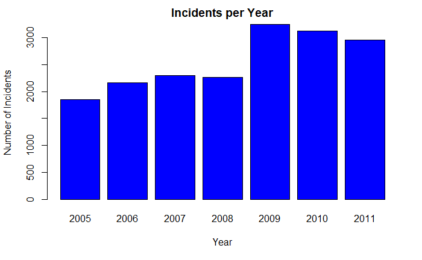

```r
# generate a dataframe for task 7.
task7 <- dbGetQuery(conn = mysqlconnection, statement = "SELECT Number_of_incidents,
                    YEAR FROM (SELECT COUNT(*) As Number_of_incidents,
                    DATE_FORMAT(flight_date, '%Y') As YEAR FROM incidents GROUP BY
                    YEAR(flight_date)) As sub HAVING YEAR > 2004 ORDER BY YEAR ASC;")

# define the column needed to plot.
input <- task7[, c('YEAR', 'Number_of_incidents')]

# change the year to integer data type
input$YEAR <- as.integer(input$YEAR)

# plot the input dataframe
barplot(input$Number_of_incidents, names.arg = input$YEAR, xlab = "Year",
        ylab = "Number of Incidents", col = "blue", main = "Incidents per Year")
```

Task 8(15pts / 3hrs):

Stored procedure in MySQL.

```r
dbExecute(conn = mysqlconnection, statement = "CREATE PROCEDURE sp_AddBirdStrikeIncident(
            IN p_rid INT, IN p_flight_date Date, IN p_airportName VARCHAR(255),
            IN p_state VARCHAR(50), IN p_airline VARCHAR(255), IN p_aircraft VARCHAR(50),
            IN p_mflight_phase VARCHAR(50), IN p_altitude_ft INT, IN p_sky_condition VARCHAR(50),
            IN p_pilot_warned_flag BOOLEAN)
          BEGIN
            INSERT INTO incidents(rid, flight_date, origin, airline, aircraft, mflight_phase,
              altitude_ft, msky_conditions, pilot_warned_flag)
              VALUES(p_rid, p_flight_date, (SELECT aid+1 FROM airports ORDER BY aid DESC LIMIT 1),
              p_airline, p_aircraft, p_mflight_phase, p_altitude_ft, (SELECT cid FROM conditions
              WHERE sky_conditions = p_sky_condition), p_pilot_warned_flag);
            INSERT INTO airports(aid, airportName, airportCode, state)
              VALUES((SELECT origin FROM incidents WHERE rid = p_rid), p_airportName, '', p_state);
          END")
```

```
[1] 0
```

Execute the stored procedure according to defined value to add a bird strike incident. rid = 25342 flight_date = ‘2022-06-29’ airportName = ‘New Brookline International Airport’ state = ‘Massachusettes’ airline = ‘JetBlue’ aircraft = ‘Airplane’ flight_phase = ‘takeoff’ altitude_ft = 3000 sky_condition = ‘Some Cloud’ pilot_warned_flag = 0(FALSE)

```r
dbExecute(conn = mysqlconnection, statement = "CALL sp_AddBirdStrikeIncident(25342, '2022-06-29',
          'New Brookline International Airport', 'Massachusettes', 'JetBlue', 'Airplane',
          'takeoff', 3000, 'Some Cloud', 0)");
```

```
[1] 1
```

Show the added airport ‘New Brookline International Airport’. Using R.

```r
db_query_NBIA <- dbGetQuery(conn = mysqlconnection, statement ="SELECT * FROM airports
                            WHERE state = 'Massachusettes';")
db_query_NBIA
```

| aid | airportName | airportCode | state |
| --- | --- | --- | --- |
| 1110 | New Brookline International Airport |  | Massachusettes |

Show the added bird strike incident rid = 25342. Using R.

```r
db_query_25342 <- dbGetQuery(conn = mysqlconnection, statement ="SELECT * FROM incidents
                             WHERE rid = 25342;")
db_query_25342
```

| rid | flight_date | origin | airline | aircraft | mflight_phase | altitude_ft | msky_conditions | pilot_warned_flag |
| --- | --- | --- | --- | --- | --- | --- | --- | --- |
| 25342 | 2022-06-29 | 1110 | JetBlue | Airplane | takeoff | 3000 | 3 | 0 |

Show the new number of incidents. Increment by 1 due to execution of stored procedure. Using R.

```r
db_query_incidents <- dbGetQuery(conn = mysqlconnection, statement = "SELECT * FROM incidents;")
numRows_db_query_numIncidents <- nrow(db_query_incidents)
print(paste0("New number of incidents = ", numRows_db_query_numIncidents))
```

```
[1] "New number of incidents = 25341"
```

Show the new number of airports. Increment by 1 due to execution of stored procedure. Using R.

```r
db_query_airports <- dbGetQuery(conn = mysqlconnection, statement = "SELECT * FROM airports;")
numRows_db_query_airports <- nrow(db_query_airports)
print(paste0("New number of airports = ", numRows_db_query_airports))
```

```
[1] "New number of airports = 1110"
```

Show the added airport ‘New Brookline International Airport’. Using SQL.

```sql
SELECT * FROM airports WHERE state = 'Massachusettes';
```

| aid | airportName | airportCode | state |
| --- | --- | --- | --- |
| 1110 | New Brookline International Airport |  | Massachusettes |

Show the added bird strike incident rid = 25342. Using SQL.

```sql
SELECT * FROM incidents WHERE rid = 25342;
```

| rid | flight_date | origin | airline | aircraft | mflight_phase | altitude_ft | msky_conditions | pilot_warned_flag |
| --- | --- | --- | --- | --- | --- | --- | --- | --- |
| 25342 | 2022-06-29 | 1110 | JetBlue | Airplane | takeoff | 3000 | 3 | 0 |

Show the new number of incidents. Increment by 1 due to execution of stored procedure. Using SQL.

```sql
SELECT SUM(Number_of_incidents) As "Total Incidents" FROM (SELECT COUNT(*) As Number_of_incidents,
    DATE_FORMAT(flight_date, '%m') As MONTH FROM incidents GROUP BY MONTH(flight_date)) As sub;
```

| Total Incidents |
| --- |
| 25341 |

Debug Commands:

Delete a table.

```r
dbSendQuery(mysqlconnection, "DROP TABLE IF EXISTS incidents")
```

Delete a table.

```r
dbSendQuery(mysqlconnection, "DROP TABLE IF EXISTS airports")
```

```r
dbSendQuery(mysqlconnection, "DROP TABLE IF EXISTS conditions")
```

```r
dbSendQuery(mysqlconnection, "DROP TABLE IF EXISTS flight_phase_enum")
```

Disconnect the mysqlconnection.

```r
dbDisconnect(mysqlconnection);
dbDisconnect(sqliteconnection);
```

Disconnect all existing connections in MySQL.

```r
dbDisconnectAll <- function(){
  disconnectAll <- length(dbListConnections(MySQL())  )
  lapply( dbListConnections(MySQL()), function(x) dbDisconnect(x) )
  cat(sprintf("%s connection(s) closed.\n", disconnectAll))
}
```

```r
dbDisconnectAll()
```

```
2 connection(s) closed.
```